# Lecture 11: PCA - Applications

Zhaoxia Yu

Professor, Department of Statistics

2026-05-31

```r
knitr::opts_chunk$set(echo = TRUE)
library(tidyr) #the pipe (%>%) tool is extremely useful
library(MASS)
library(tidyverse)
```

# Apply PCA to Data

## Estimate $\boldsymbol \Sigma$.

- We have discussed how to find PCs for a random vector $\mathbf X_{p\times 1} \sim (0, \boldsymbol \Sigma)$, where $\boldsymbol \Sigma$ is a known covariance matrix.
- In practice,
  - the observed data is an $n\times p$ data matrix $\mathbf X_{n\times p}$
  - $\boldsymbol \Sigma$ is unknown, which can be estimated by the sample covariance matrix $\mathbf S$.

## Apply PCA to A Data Set: Steps

1. Estimate $\boldsymbol \Sigma$ by the sample covariance matrix $\mathbf S$
2. Compute the eigenvectors of $\mathbf S$, and denote them by $\gamma_1, \cdots, \gamma_p$
3. Compute the PCs
- PC1: $Y_1=\mathbf X \gamma_1$, which is a $n\times 1$ vector
- PC2: $Y_2=\mathbf X \gamma_2$, which is a $n\times 1$ vector
- $\cdots \cdots$
- PCi: $Y_i=\mathbf X \gamma_i$, which is a $n\times 1$ vector
- Equivalently, compute
  $$Y_{pc}=\mathbf X \Gamma$$
  which is the $n\times p$ matrix with the $i$th column being the $i$th PC.

# Example: Iris Data

## Outline

- PCA using raw data
- PCA using centered data
- PCA using standardized data
- Scree plot
- Biplot

# PCA Using Raw Data

## Estimate $\boldsymbol \Sigma$

```r
#########################################################
## iris data
##rearrange the data such as the response matrix is an n-by-p matrix
Y=cbind(SepalL=c(iris3[,1,1],iris3[,1,2],iris3[,1,3]),
SepalW=c(iris3[,2,1],iris3[,2,2],iris3[,2,3]),
PetalL=c(iris3[,3,1],iris3[,3,2],iris3[,3,3]),
PetalW=c(iris3[,4,1],iris3[,4,2],iris3[,4,3]))
#for unknown reasons, data.frame won't work but cbind works
#alternatively, we can use the following way to define y
#y=aperm(iris3,c(1,3,2));dim(y)=c(150,4)
S=cov(Y)
S
```

```
           SepalL     SepalW     PetalL     PetalW
SepalL  0.6856935 -0.0424340  1.2743154  0.5162707
SepalW -0.0424340  0.1899794 -0.3296564 -0.1216394
PetalL  1.2743154 -0.3296564  3.1162779  1.2956094
PetalW  0.5162707 -0.1216394  1.2956094  0.5810063
```

## Compute PCs

```r
Gamma=eigen(S)$vectors
eigen.val=eigen(S)$values
gamma1=Gamma[,1]
gamma2=Gamma[,2]
gamma3=Gamma[,3]
gamma4=Gamma[,4]
# The four pcs:
pc1=Y%*%gamma1
pc2=Y%*%gamma2
pc3=Y%*%gamma3
pc4=Y%*%gamma4
# Equivalently, we can obtain the nx4 matrix of PCs
PCs=Y%*%Gamma
```

## The Loadings (Weights)

```r
gamma1
```

```
[1]  0.36138659 -0.08452251  0.85667061  0.35828920
```

```r
gamma2
```

```
[1] -0.65658877 -0.73016143  0.17337266  0.07548102
```

```r
gamma3
```

```
[1] -0.58202985  0.59791083  0.07623608  0.54583143
```

```r
gamma4
```

```
[1]  0.3154872 -0.3197231 -0.4798390  0.7536574
```

## Visualize PC1 and PC2

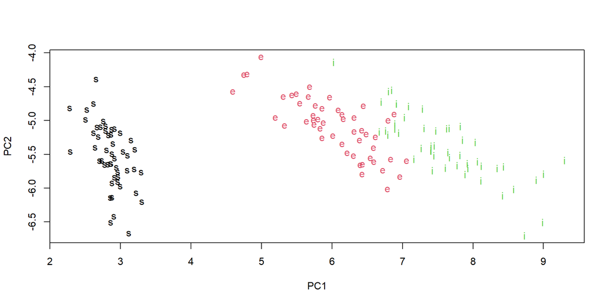

```r
plot(pc1,pc2,xlab="PC1", ylab="PC2", type="n")
points(pc1[1:50], pc2[1:50], col=1, pch="s")
points(pc1[51:100], pc2[51:100], col=2, pch="e")
points(pc1[101:150], pc2[101:150], col=3, pch="i")
```

## Proportions of Variation Explained (Cumulative)

```r
cumsum(eigen.val/sum(eigen.val))
```

```
[1] 0.9246187 0.9776852 0.9947878 1.0000000
```

```r
plot(cumsum(eigen.val)/sum(eigen.val), type="b", main="Iris Data: Variation Explained",
ylab="eigenvalues")
```

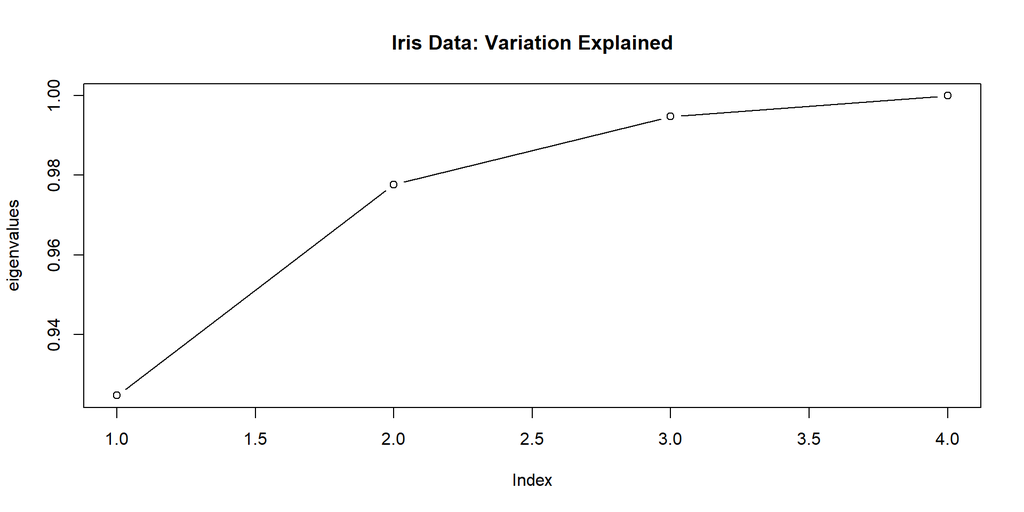

## The PCs from R

```r
#help(princomp), pay attention to fix_sign
obj=princomp(Y)
names(obj)
```

```
[1] "sdev"     "loadings" "center"   "scale"    "n.obs"    "scores"   "call"
```

```r
#help(loadings), pay attention to cutoff
#check loadings and scores to verify that
#they are same as what we calculated
```

## The PCs from R vs our PCs

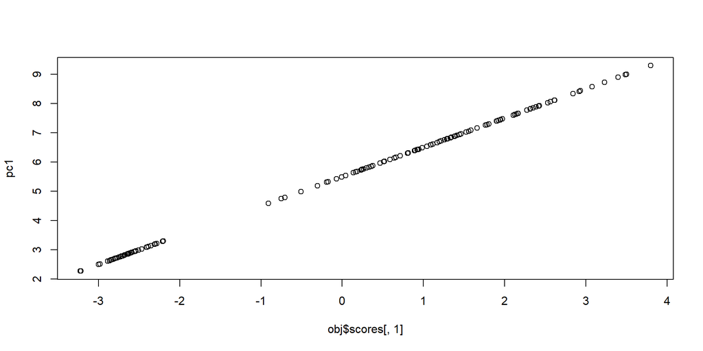

```r
plot(obj$scores[,1], pc1)
```

- The diffence is due to not centering vs centering

# PCA Using Centered Data

```r
# The four pcs:
pc1_c=scale(Y, scale=FALSE)%*%gamma1
pc2_c=scale(Y, scale=FALSE)%*%gamma2
pc3_c=scale(Y, scale=FALSE)%*%gamma3
pc4_c=scale(Y, scale=FALSE)%*%gamma4
# or
PCs_c=scale(Y, scale=FALSE)%*%Gamma
```

## R Uses Centered Data to Compute PCA

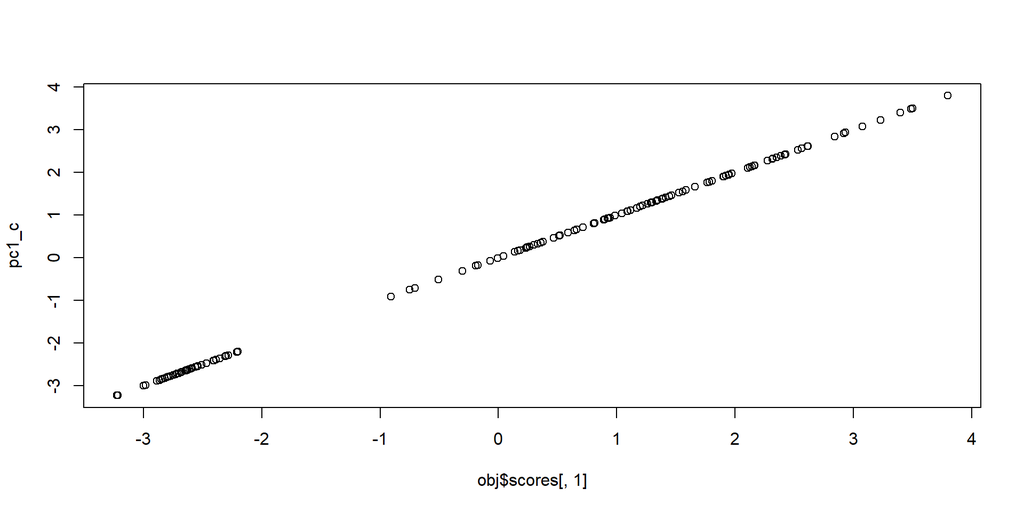

```r
plot(obj$scores[,1], pc1_c)
```

- They are identical

# PCA Using Standardized Data

## Covariance of Standardized Data

- The covariance matrix using standardized data

```r
cov(scale(Y, scale=TRUE))
```

```
           SepalL     SepalW     PetalL     PetalW
SepalL  1.0000000 -0.1175698  0.8717538  0.8179411
SepalW -0.1175698  1.0000000 -0.4284401 -0.3661259
PetalL  0.8717538 -0.4284401  1.0000000  0.9628654
PetalW  0.8179411 -0.3661259  0.9628654  1.0000000
```

## Correlation Matrix

- The correlation matrix is the covariance matrix of standardized data

```r
cor(Y)
```

```
           SepalL     SepalW     PetalL     PetalW
SepalL  1.0000000 -0.1175698  0.8717538  0.8179411
SepalW -0.1175698  1.0000000 -0.4284401 -0.3661259
PetalL  0.8717538 -0.4284401  1.0000000  0.9628654
PetalW  0.8179411 -0.3661259  0.9628654  1.0000000
```

## PCA Based on Correlation Matrix

```r
gamma1_s=eigen(cor(Y))$vectors[,1]
gamma2_s=eigen(cor(Y))$vectors[,2]
gamma3_s=eigen(cor(Y))$vectors[,3]
gamma4_s=eigen(cor(Y))$vectors[,4]
```

## The PCs based on Correlation Matrix

```r
PCs_s=scale(Y)%*% eigen(cor(Y))$vectors
colnames(PCs_s)=c("PC1", "PC2", "PC3", "PC4")
head(PCs_s)
```

```
           PC1        PC2         PC3          PC4
[1,] -2.257141 -0.4784238  0.12727962  0.024087508
[2,] -2.074013  0.6718827  0.23382552  0.102662845
[3,] -2.356335  0.3407664 -0.04405390  0.028282305
[4,] -2.291707  0.5953999 -0.09098530 -0.065735340
[5,] -2.381863 -0.6446757 -0.01568565 -0.035802870
[6,] -2.068701 -1.4842053 -0.02687825  0.006586116
```

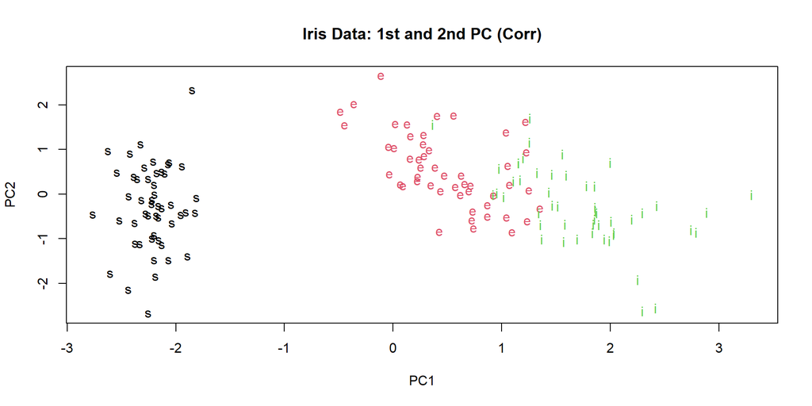

```r
plot(PCs_s[,1:2], xlab="PC1", ylab="PC2",
     main="Iris Data: 1st and 2nd PC (Corr)", type="n")
points(PCs_s[1:50, 1:2], col=1, pch="s")
points(PCs_s[51:100, 1:2], col=2, pch="e")
points(PCs_s[101:150, 1:2], col=3, pch="i")
```

## PCA with Standardized Data in R

- The princomp function in R has an option to use correlation matrix rather than covariance matrix

```r
obj.cor=princomp(Y, cor=TRUE)
```

## Standardized vs Not-Standardized

- Loadings

```r
obj$loadings[,1:4]
```

```
            Comp.1      Comp.2      Comp.3     Comp.4
SepalL  0.36138659  0.65658877  0.58202985  0.3154872
SepalW -0.08452251  0.73016143 -0.59791083 -0.3197231
PetalL  0.85667061 -0.17337266 -0.07623608 -0.4798390
PetalW  0.35828920 -0.07548102 -0.54583143  0.7536574
```

```r
obj.cor$loading[,1:4]
```

```
           Comp.1     Comp.2     Comp.3     Comp.4
SepalL  0.5210659 0.37741762  0.7195664  0.2612863
SepalW -0.2693474 0.92329566 -0.2443818 -0.1235096
PetalL  0.5804131 0.02449161 -0.1421264 -0.8014492
PetalW  0.5648565 0.06694199 -0.6342727  0.5235971
```

## PCA based on Cov vs Cor: 1st and 2nd PC

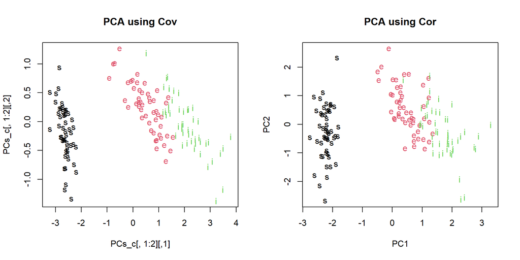

```r
par(mfrow=c(1,2))
plot(PCs_c[,1:2], main="PCA using Cov", type="n")
points(PCs_c[1:50, 1:2], col=1, pch="s")
points(PCs_c[51:100, 1:2], col=2, pch="e")
points(PCs_c[101:150, 1:2], col=3, pch="i")
plot(PCs_s[,1:2], main="PCA using Cor", type="n")
points(PCs_s[1:50, 1:2], col=1, pch="s")
points(PCs_s[51:100, 1:2], col=2, pch="e")
points(PCs_s[101:150, 1:2], col=3, pch="i")
```

## PCA based on Cov vs Cor: Variance Explained (Cumulatively)

```r
par(mfrow=c(1,2))
cumsum(eigen(cov(Y))$values)/sum(eigen(cov(Y))$values)
plot(cumsum(eigen(cov(Y))$values)/sum(eigen(cov(Y))$values),
     type="b", main="Iris Data: Cov",ylab="Cum Variance Explained")
cumsum(eigen(cor(Y))$values)/sum(eigen(cor(Y))$values)
plot(cumsum(eigen(cor(Y))$values)/sum(eigen(cor(Y))$values),
     type="b", main="Iris Data: Cor",ylab="Cum Variance Explained")
```

```
[1] 0.9246187 0.9776852 0.9947878 1.0000000
```

```
[1] 0.7296245 0.9581321 0.9948213 1.0000000
```

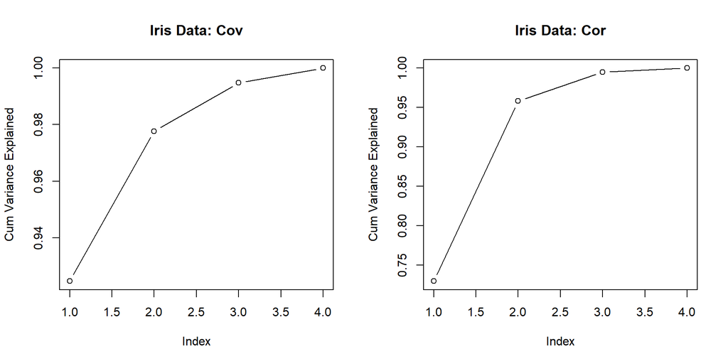

## PCA based on Cov vs Cor: Variances (Scree Plot)

```r
par(mfrow=c(1,2))
plot(princomp(Y), type="l")
plot(princomp(Y, cor=TRUE), type="l")
```

[output not shown]

## PCA based on Cov vs Cor: Variances (Scree Plot)

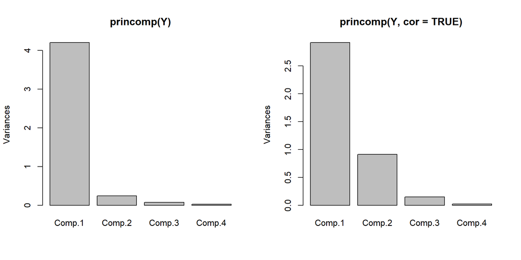

```r
par(mfrow=c(1,2))
plot(princomp(Y))
plot(princomp(Y, cor=TRUE))
```

## Visualizing PCA

- We have seen scree plots for visualizing the variance explained by each PC
- Biplots are another way to visualize PCA results
- A biplot is a visualization tool that combines:
  - Scores (projected data points)
  - Loadings (variable vectors) from Principal Component Analysis (PCA).
- A biplot shows relationships between observations and between variables in reduced dimensions (e.g., PC1 vs. PC2).

## Biplot: loadings

```r
obj$loadings
```

```
Loadings:
       Comp.1 Comp.2 Comp.3 Comp.4
SepalL  0.361  0.657  0.582  0.315
SepalW         0.730 -0.598 -0.320
PetalL  0.857 -0.173        -0.480
PetalW  0.358        -0.546  0.754

               Comp.1 Comp.2 Comp.3 Comp.4
SS loadings      1.00   1.00   1.00   1.00
Proportion Var   0.25   0.25   0.25   0.25
Cumulative Var   0.25   0.50   0.75   1.00
```

## Biplot

```r
biplot(obj, col=c(8,2), main="Iris Data: Biplot")
```

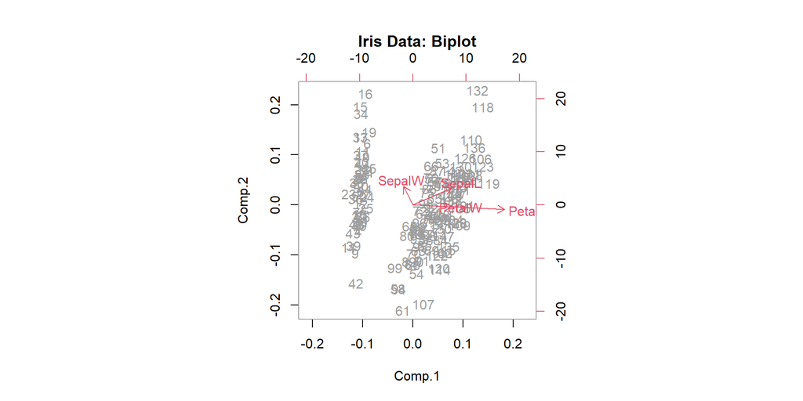

## Biplot: the scale parameter

- The loadings and scores often have very different scales.
- The scale parameter harmonizes them for visualization.
- The default value is 1, which means the loadings are scaled by 1 and the scores are scaled by 1, i.e., cores and loadings are scaled equally.
- Make scale < 1 if variable arrows are too small to interpret.
- Use scale > 1 if data points are too crowded.

# Example: Wine Data

## The Wine Data

```r
wine = read.csv("http://archive.ics.uci.edu/ml/machine-learning-databases/wine-quality/winequality-white.csv", sep = ";")
dim(wine)
```

```
[1] 4898   12
```

```r
head(wine)
```

```
  fixed.acidity volatile.acidity citric.acid residual.sugar chlorides
1           7.0             0.27        0.36           20.7     0.045
2           6.3             0.30        0.34            1.6     0.049
3           8.1             0.28        0.40            6.9     0.050
4           7.2             0.23        0.32            8.5     0.058
5           7.2             0.23        0.32            8.5     0.058
6           8.1             0.28        0.40            6.9     0.050
  free.sulfur.dioxide total.sulfur.dioxide density   pH sulphates alcohol
1                  45                  170  1.0010 3.00      0.45     8.8
2                  14                  132  0.9940 3.30      0.49     9.5
3                  30                   97  0.9951 3.26      0.44    10.1
4                  47                  186  0.9956 3.19      0.40     9.9
5                  47                  186  0.9956 3.19      0.40     9.9
6                  30                   97  0.9951 3.26      0.44    10.1
  quality
1       6
2       6
3       6
4       6
5       6
6       6
```

## PCA based on Cov vs Cor: Variance Explained

```r
par(mfrow=c(1,2))
cumsum(eigen(cov(wine))$values)/sum(eigen(cov(wine))$values)
plot(cumsum(eigen(cov(wine))$values)/sum(eigen(cov(wine))$values),
     type="b", main="Wine Data: Cov",ylab="Cum Variance Explained")
cumsum(eigen(cor(wine))$values)/sum(eigen(cor(wine))$values)
plot(cumsum(eigen(cor(wine))$values)/sum(eigen(cor(wine))$values),
     type="b", main="Wine Data: Cor",ylab="Cum Variance Explained")
```

```
 [1] 0.9093312 0.9886453 0.9987968 0.9994164 0.9997397 0.9999753 0.9999839
 [8] 0.9999906 0.9999960 0.9999998 1.0000000 1.0000000
```

```
 [1] 0.2788891 0.4110633 0.5253276 0.6157327 0.6970063 0.7752366 0.8393406
 [8] 0.8996651 0.9460402 0.9746180 0.9982942 1.0000000
```

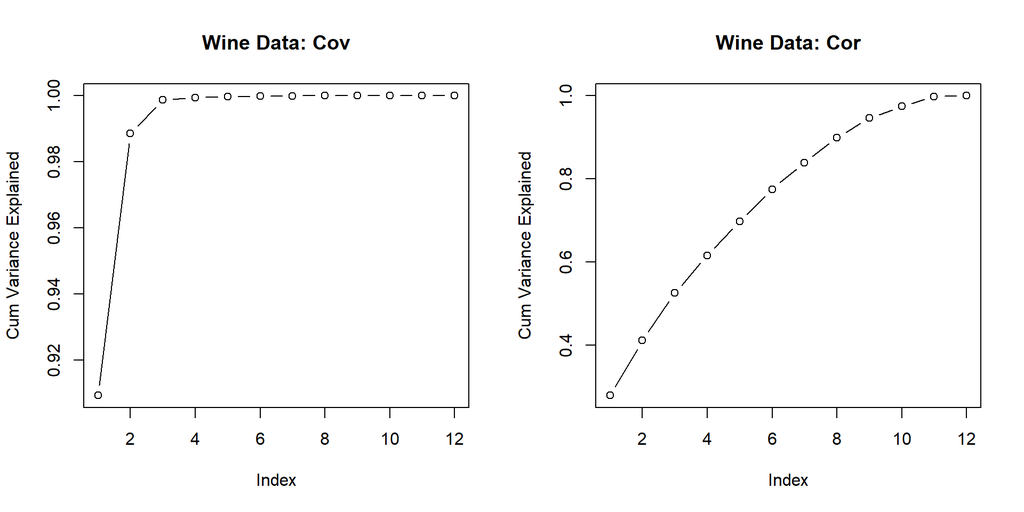

## PCA based on Cov vs Cor: Variances (Scree Plot)

```r
par(mfrow=c(1,2))
plot(princomp(wine), type="l")
plot(princomp(wine, cor=TRUE), type="l")
```

[output not shown]

## PCA based on Cov vs Cor: Variances (Scree Plot)

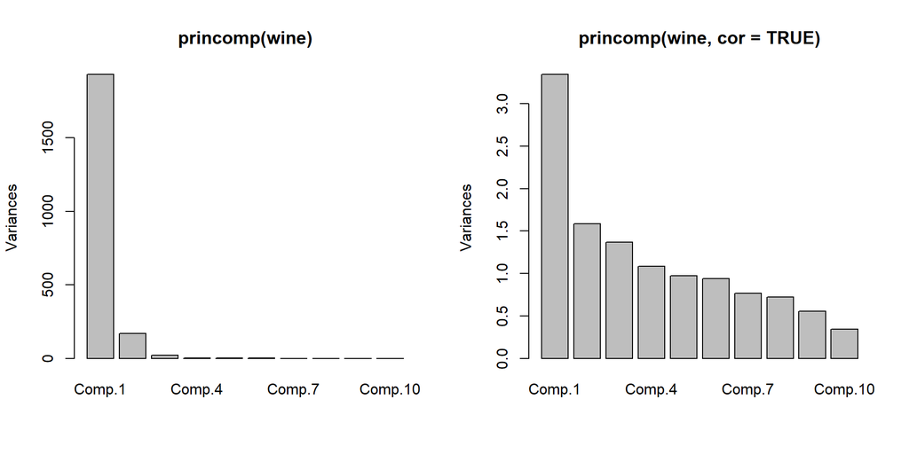

```r
par(mfrow=c(1,2))
plot(princomp(wine))
plot(princomp(wine, cor=TRUE))
```

## PCA based on Cov vs Cor: Loadings of 1st PC

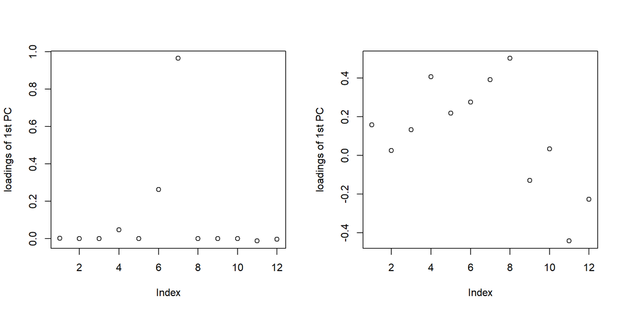

```r
par(mfrow=c(1,2))
plot(princomp(wine)$loadings[,1], ylab="loadings of 1st PC")
plot(princomp(wine, cor=TRUE)$loadings[,1], ylab="loadings of 1st PC")
```

## Wine Data: PCA_COV and PCA_COR Are Different

- In the wine data, raw data and standardized data give very different results
- Raw Data: the first PC dominants the rest
- Standardized data: the variances of the PCs are less different
- Why?

## Wine Data: The measurements

- There are 12 measurements / features in the wine data
- The variances are very different

```r
apply(wine, 2, var)
```

```
       fixed.acidity     volatile.acidity          citric.acid
        7.121136e-01         1.015954e-02         1.464579e-02
      residual.sugar            chlorides  free.sulfur.dioxide
        2.572577e+01         4.773337e-04         2.892427e+02
total.sulfur.dioxide              density                   pH
        1.806085e+03         8.945524e-06         2.280118e-02
           sulphates              alcohol              quality
        1.302471e-02         1.514427e+00         7.843557e-01
```

## Standardized vs Not-Standardized

- PCA depends on the measurement scale
- When features are not standardized, the leading PCs tend to give larger loadings for features with large variances
- When similar variables are measured using different units, standardization is typically recommended before PCA

# Choose $k$

## Choose the Number of PCs

- A rule of thumb? Choose the PC’s that contain more information than the average amount of information per PC.
- People often choose $k$ such that at least a certain percentage of the total variance is explained. E.g., 80%, 90%, 95%, 99%
- Scree Plots:
  - A scree plot is a plot of the eigenvalues against the number of PCs
  - we look for an “elbow point” where the decrease in eigenvalues becomes less steep. The number of PCs corresponding to the elbow point can be chosen.
- No unified solution. The choice of the number of PCs may depend on the specific problem

## Choose the Number of PCs

- Balancing dimensionality reduction and information retention.
- Too few PCs may result in significant loss of information
- Too many PCS is not efficient in dimension reduction application or research question

# The Remaining Lectures

- Lec 12: Linear Discriminant Analysis
- Lec 13: Linear Discriminant Analysis
- Lec 14: Factor Analysis
- Lec 15: Cluster Analysis
- Lec 16: Canonical Analysis
- Lec 17: Structural Equation Modeling
- Lec 18: Conclusion